# Assigment11

```python
import pandas as pd
import seaborn as sns
```

```python
penguins = sns.load_dataset("penguins")
PremStats = pd.read_csv("../data/EPL_20_21.csv")
```

```python
PremStats.head()
```

|  | Name | Club | Nationality | Position | Age | Matches | Starts | Mins | Goals | Assists | Passes_Attempted | Perc_Passes_Completed | Penalty_Goals | Penalty_Attempted | xG | xA | Yellow_Cards | Red_Cards |
| --- | --- | --- | --- | --- | --- | --- | --- | --- | --- | --- | --- | --- | --- | --- | --- | --- | --- | --- |
| 0 | Mason Mount | Chelsea | ENG | MF,FW | 21 | 36 | 32 | 2890 | 6 | 5 | 1881 | 82.3 | 1 | 1 | 0.21 | 0.24 | 2 | 0 |
| 1 | Edouard Mendy | Chelsea | SEN | GK | 28 | 31 | 31 | 2745 | 0 | 0 | 1007 | 84.6 | 0 | 0 | 0.00 | 0.00 | 2 | 0 |
| 2 | Timo Werner | Chelsea | GER | FW | 24 | 35 | 29 | 2602 | 6 | 8 | 826 | 77.2 | 0 | 0 | 0.41 | 0.21 | 2 | 0 |
| 3 | Ben Chilwell | Chelsea | ENG | DF | 23 | 27 | 27 | 2286 | 3 | 5 | 1806 | 78.6 | 0 | 0 | 0.10 | 0.11 | 3 | 0 |
| 4 | Reece James | Chelsea | ENG | DF | 20 | 32 | 25 | 2373 | 1 | 2 | 1987 | 85.0 | 0 | 0 | 0.06 | 0.12 | 3 | 0 |

## Portfolio assignment 11

#### 20 min: Do a Numerical VS Categorical bivariate analysis on the penguins dataset.

Choose one of the categorical columns: species, island or sex use .groupby('').mean() too look at the means of the numerical columns. Does it look like there is a difference between categories? Use the seaborn barplot to plot the mean and confidence. Create this plot for each of the numerical columns (bill_length_mm bill_depth_mm, flipper_length_mm, body_mass_g) For each of the plots, write a conclusion: Is there a statistically significant difference for this numerical column for each category? Optional: Repeat this proces for the other two categorical columns As seen below the Biscoe island shows values that are off compared to the values on the Dream and Torgersen island.

```python
penguins.groupby(["island"]).mean()
```

| island | bill_length_mm | bill_depth_mm | flipper_length_mm | body_mass_g |
| --- | --- | --- | --- | --- |
| Biscoe | 45.257485 | 15.874850 | 209.706587 | 4716.017964 |
| Dream | 44.167742 | 18.344355 | 193.072581 | 3712.903226 |
| Torgersen | 38.950980 | 18.429412 | 191.196078 | 3706.372549 |

De bill length zit er vooral verschil tussen de Dream en Torgersen. terwijl bij de diepte, flipper lengte, en body mass is er juist een verschil tussen Dream en Torgersen en de Biscoe.

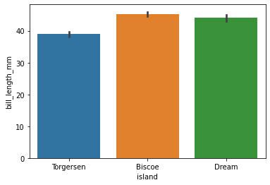

```python
sns.barplot(y="bill_length_mm", x="island", data=penguins)
```

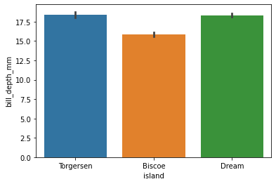

```python
sns.barplot(y="bill_depth_mm", x="island", data=penguins)
```

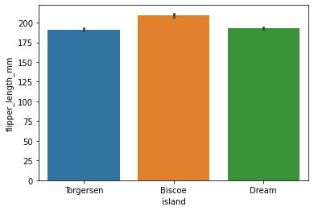

```python
sns.barplot(y="flipper_length_mm", x="island", data=penguins)
```

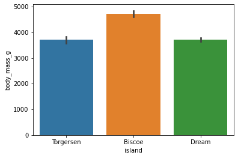

```python
sns.barplot(y="body_mass_g", x="island", data=penguins)
```